# Лабораторная работа №6

Решение моделей в непрерывном и дискретном времени

Александр Эдуардович Аскеров

Российский университет дружбы народов

2025-11-22

# Информация

## Докладчик

- Аскеров Александр Эдуардович
- Кафедра теории вероятностей и кибербезопасности
- Российский университет дружбы народов им. П. Лумумбы

# Вводная часть

## Цель работы

Основной целью работы является освоение специализированных пакетов для решения задач в непрерывном и дискретном времени.

## Задание

1. Используя Jupyter Lab, повторите примеры из раздела 6.2.
2. Выполните задания для самостоятельной работы.

# Модель экспоненциального роста

[figure not shown]

Рисунок 1: Модель экспоненциального роста 1

# Модель экспоненциального роста

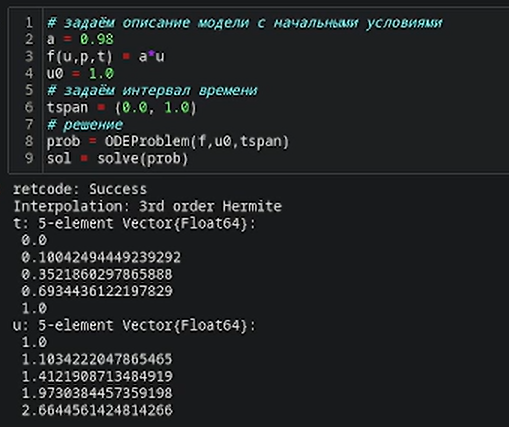

Рисунок 2: Модель экспоненциального роста 2

# Модель экспоненциального роста

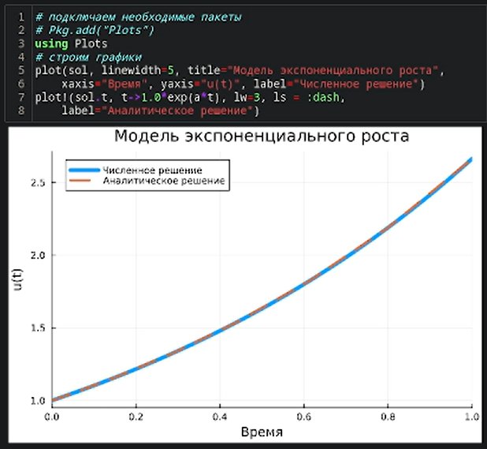

Рисунок 3: Модель экспоненциального роста 3

# Модель экспоненциального роста

[figure not shown]

Рисунок 4: Модель экспоненциального роста 4

# Модель экспоненциального роста

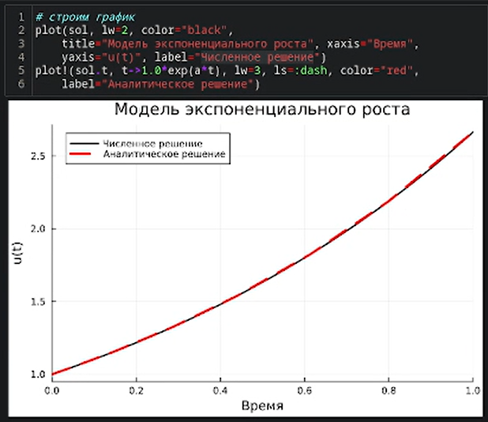

Рисунок 5: Модель экспоненциального роста 5

# Система Лоренца

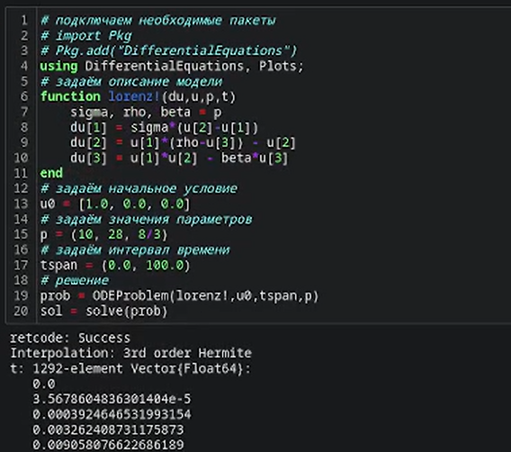

Рисунок 6: Система Лоренца 1

# Система Лоренца

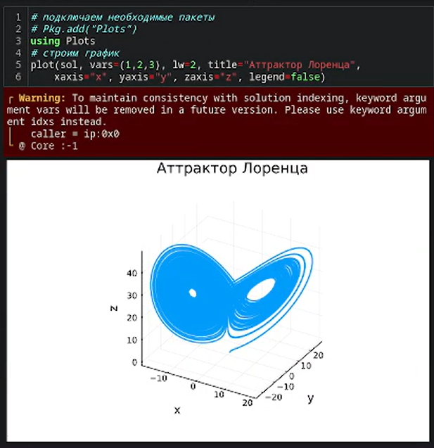

Рисунок 7: Система Лоренца 2

# Система Лоренца

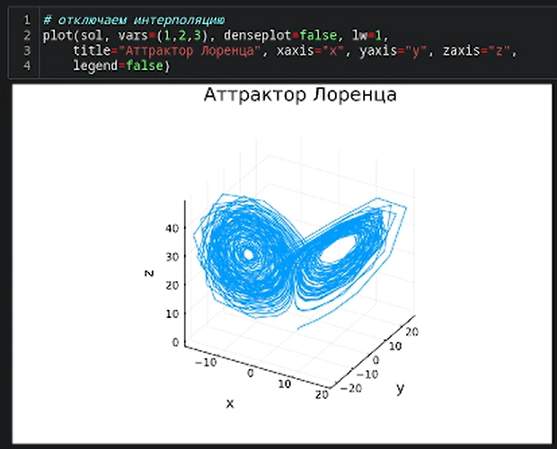

Рисунок 8: Система Лоренца 3

# Модель Лотки–Вольтерры

[figure not shown]

Рисунок 9: Модель Лотки–Вольтерры 1

# Модель Лотки–Вольтерры

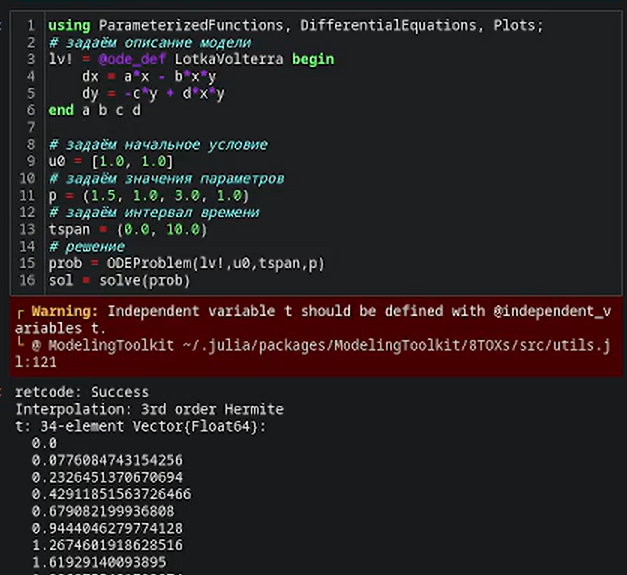

Рисунок 10: Модель Лотки–Вольтерры 2

# Модель Лотки–Вольтерры

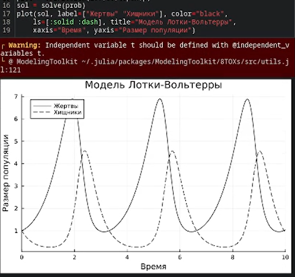

Рисунок 11: Модель Лотки–Вольтерры 3

# Модель Лотки–Вольтерры

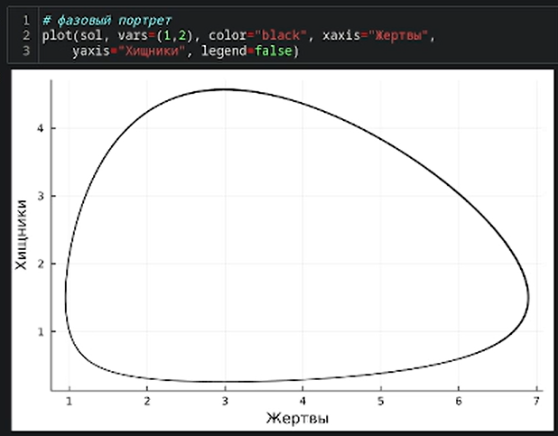

Рисунок 12: Модель Лотки–Вольтерры 4

# Задания для самостоятельного выполнения

№1.

Реализуем и проанализируем модель роста численности изолированной популяции (модель Мальтуса):

$$\dot x = ax, \quad a = b – c,$$

где $x(t)$ – численность изолированной популяции в момент времени $t$, $a$ – коэффициент роста популяции, $b$ – коэффициент рождаемости, $c$ – коэффициент смертности. Построим соответствующие графики (в том числе с анимацией).

# Задания для самостоятельного выполнения

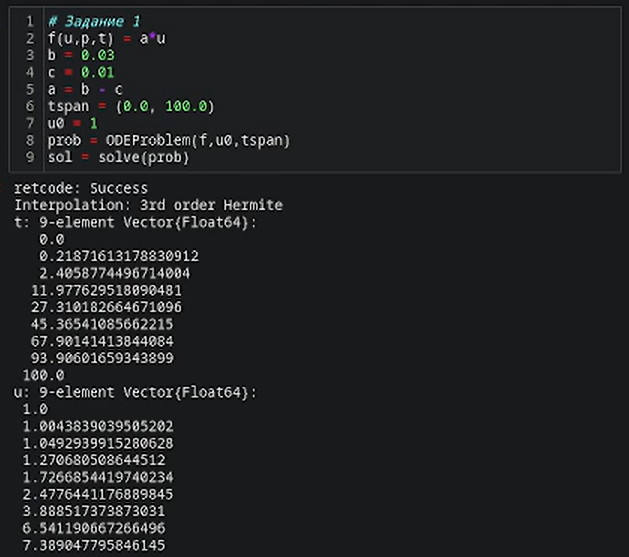

Рисунок 13: Решение

# Задания для самостоятельного выполнения

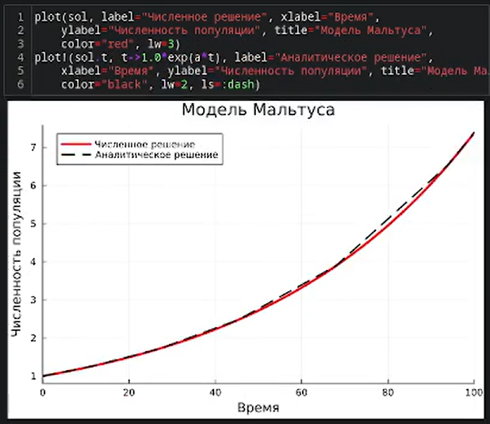

Рисунок 14: График

# Задания для самостоятельного выполнения

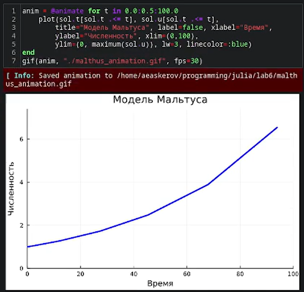

Рисунок 15: Анимация

# Задания для самостоятельного выполнения

№2.

Реализуем и проанализируем логистическую модель роста популяции:

$$\dot x = rx(1 - \dfrac{x}{k}), \quad r>0, \quad k>0,$$

где $r$ – коэффициент роста популяции, $k$ – потенциальная ёмкость экологической системы (предельное значение численности популяции). Построим соответствующие графики (в том числе с анимацией).

# Задания для самостоятельного выполнения

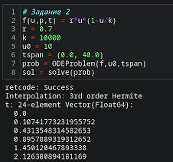

Рисунок 16: Решение

# Задания для самостоятельного выполнения

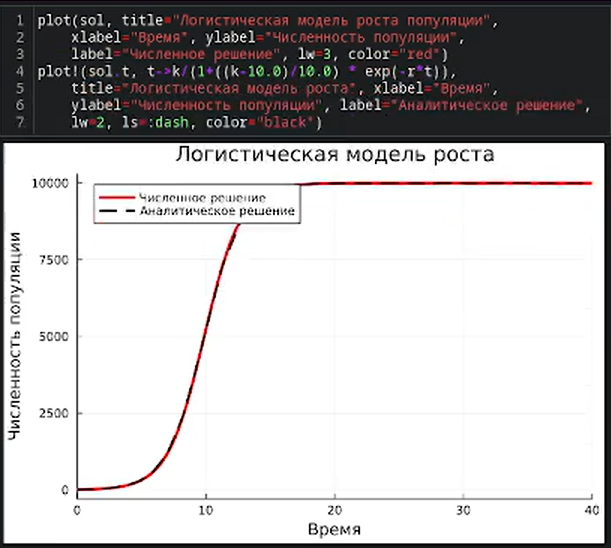

Рисунок 17: График

# Задания для самостоятельного выполнения

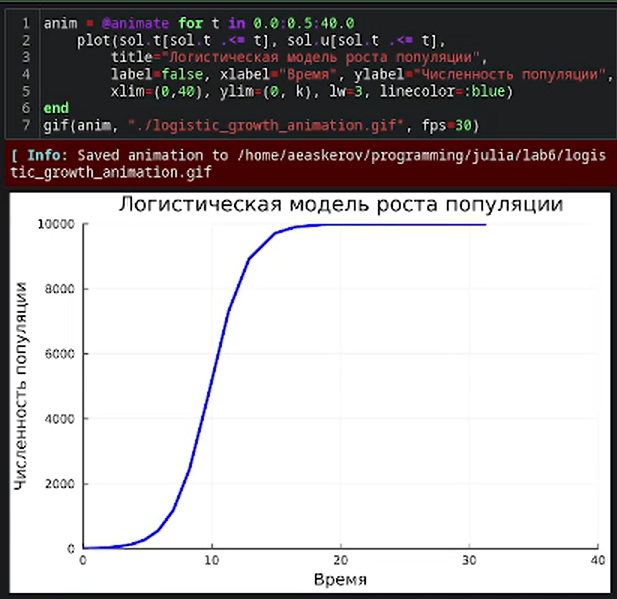

Рисунок 18: Анимация

# Задания для самостоятельного выполнения

№3.

Реализуем и проанализируем логистическую модель эпидемии Кермака–Маккендрика (SIR-модель):

$$\begin{cases}
\dot s = - \beta i s, \\
\dot i = \beta i s - \nu i, \\
\dot r = \nu i,
\end{cases}$$

# Задания для самостоятельного выполнения

где $s(t)$ – численность восприимчивых к болезни индивидов в момент времени t, $i(t)$ – численность инфицированных индивидов в момент времени t, $r(t)$ – численность переболевших индивидов в момент времени t, $N$ – это сумма этих трёх, $\beta$ – коэффициент интенсивности контактов индивидов с последующим инфицированием, $\nu$ – коэффициент интенсивности выздоровления соответственно инфицированных индивидов. Численность популяции считается постоянной, т.е. $\dot s + \dot i + \dot r = 0$. Построим соответствующие графики (в том числе с анимацией).

# Задания для самостоятельного выполнения

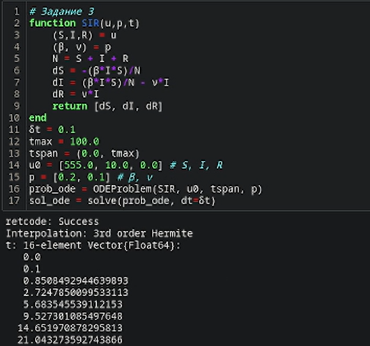

Рисунок 19: Решение

# Задания для самостоятельного выполнения

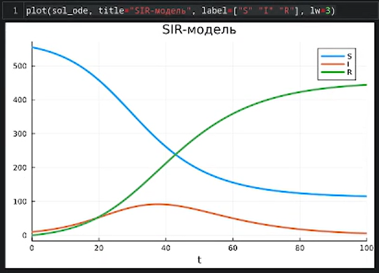

Рисунок 20: График

# Задания для самостоятельного выполнения

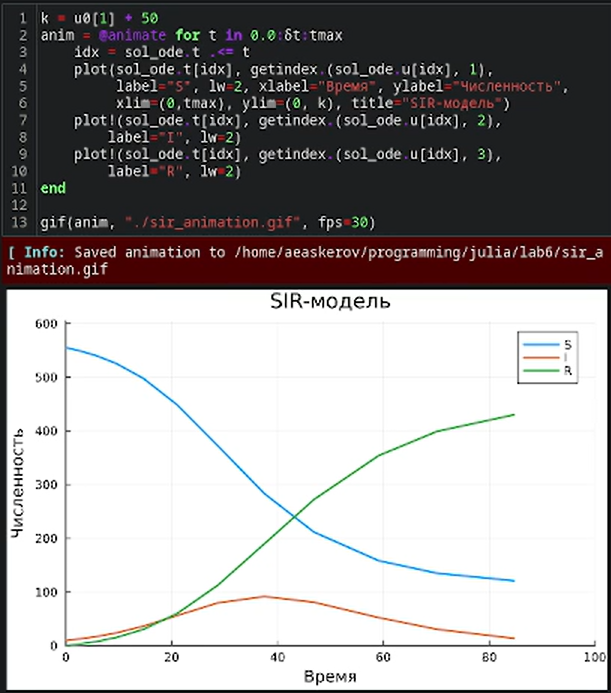

Рисунок 21: Анимация

# Задания для самостоятельного выполнения

№4.

Как расширение модели SIR (Susceptible-Infected-Removed) по результатам эпидемии испанки была предложена модель SEIR (Susceptible-Exposed-Infected-Removed).

$$\begin{cases}
\dot s(t) = - \dfrac{\beta}{N} s(t) i(t), \\
\dot e(t) = \dfrac{\beta}{N} s(t) i(t) - \delta e(t), \\
\dot i(t) = \delta e(t) - \gamma i(t), \\
\dot r(t) = \gamma i(t),
\end{cases}$$

# Задания для самостоятельного выполнения

Размер популяции сохраняется:

$$s(t) + e(t) + i(t) + r(t) = N$$

# Задания для самостоятельного выполнения

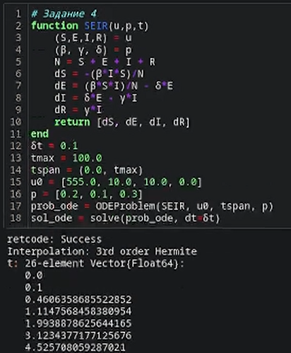

Рисунок 22: Решение

# Задания для самостоятельного выполнения

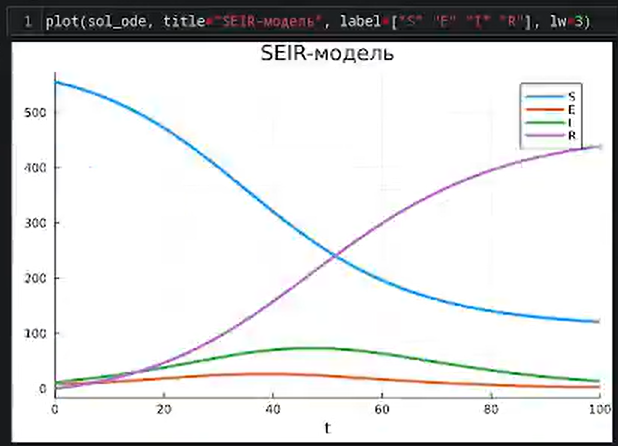

Рисунок 23: График

# Задания для самостоятельного выполнения

№5.

# Задания для самостоятельного выполнения

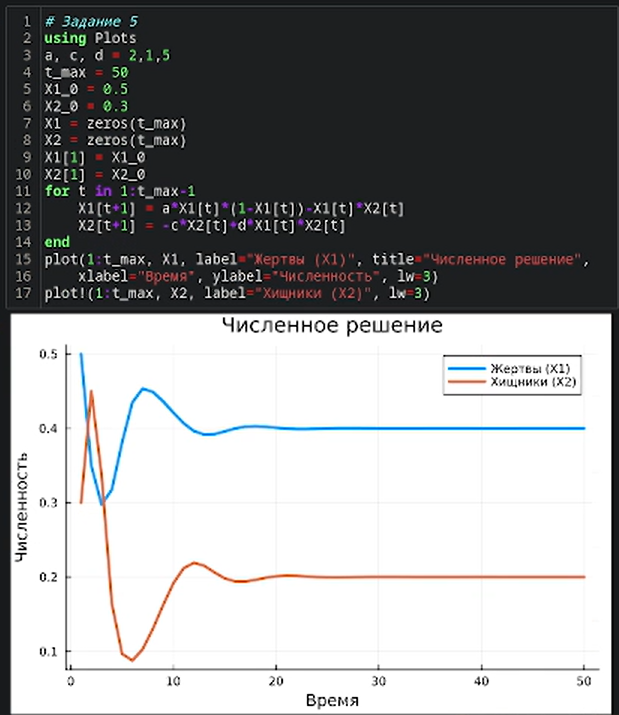

Рисунок 24: График

# Задания для самостоятельного выполнения

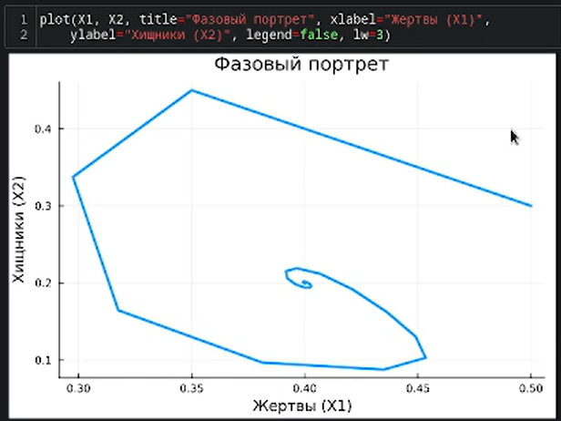

Рисунок 25: Фазовый портрет

# Задания для самостоятельного выполнения

№6.

Реализуем на языке Julia модель отбора на основе конкурентных отношений:

$$\begin{cases}
\dot x = \alpha x - \beta xy, \\
\dot y = \alpha y - \beta xy,
\end{cases}$$

Построим соответствующие графики (в том числе с анимацией) и фазовый портрет.

# Задания для самостоятельного выполнения

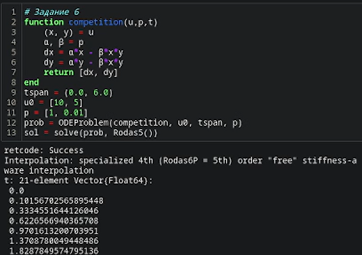

Рисунок 26: Решение

# Задания для самостоятельного выполнения

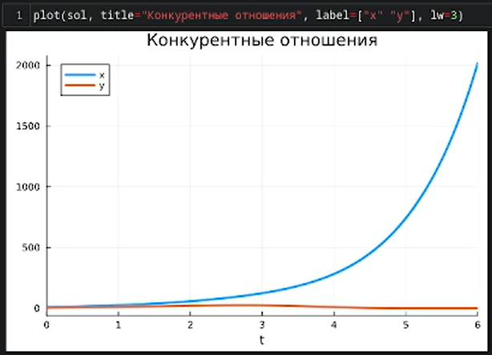

Рисунок 27: График

# Задания для самостоятельного выполнения

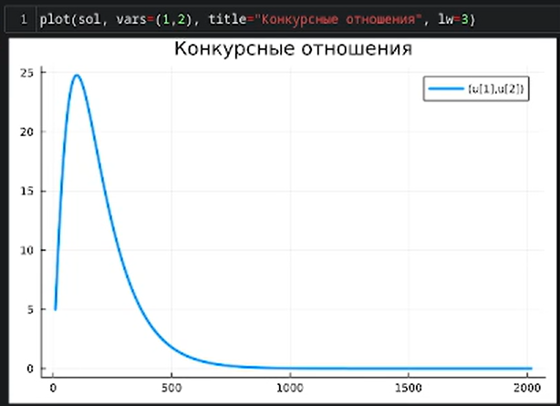

Рисунок 28: Фазовый портрет

# Задания для самостоятельного выполнения

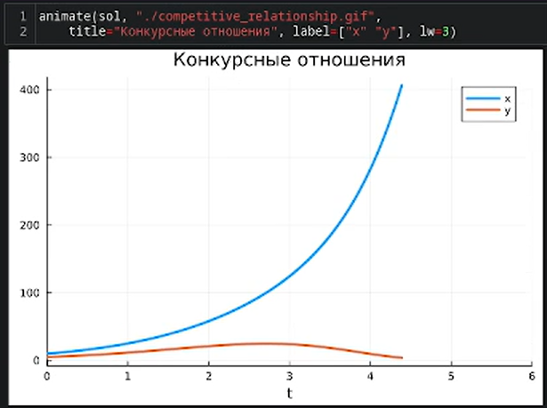

Рисунок 29: Анимация

# Задания для самостоятельного выполнения

№7.

Реализуем на языке Julia модель консервативного гармонического осциллятора:

$$\ddot x + \omega_0 ^2 = 0, x(t_0) = x_0, \dot x(t_0) = y_0,$$

# Задания для самостоятельного выполнения

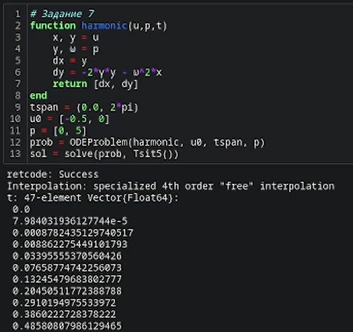

Рисунок 30: Решение

# Задания для самостоятельного выполнения

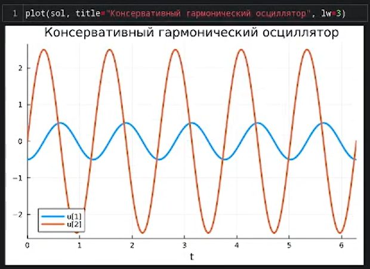

Рисунок 31: График

# Задания для самостоятельного выполнения

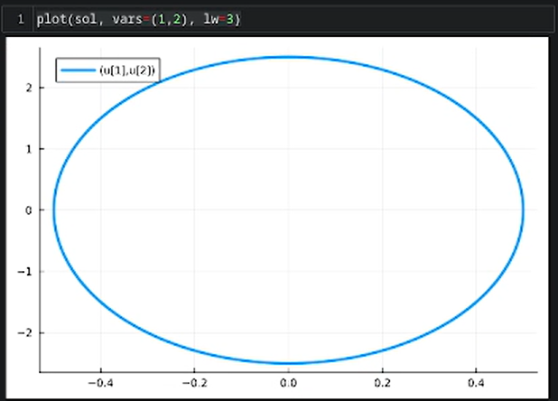

Рисунок 32: Фазовый портрет